# A Comparison of Lasso Regression and Tree-Based Methods for Salary Prediction

Sarah Campos

April 28, 2026

```r
library(glmnet)
library(randomForest)
library(gbm)
library(dplyr)

data <- read.csv("job_salary_prediction_dataset.csv", stringsAsFactors = TRUE)

data <- na.omit(data)
data$salary <- as.numeric(data$salary)
```

## 1. Introduction

Understanding the factors that influence salary is important for both individuals and organizations. Salaries vary widely depending on experience, education, job role and location, but the extent to which each factor contributes is not always clear. This project aims to model salary as a function of these characteristics and evaluate how well different predictive methods perform. The analysis uses the Job Salary Prediction Dataset obtained from Kaggle, which contains information on job roles, years of experience, education level, skills count, industry, company size, location, remote work status, certifications and salary outcomes (Kaggle, n.d.). The dataset includes a large number of observations and a mix of numerical and categorical variables, making it well-suited for comparing both linear and tree-based models. To address this problem, several models were applied, including Lasso regression as a baseline and three tree-based methods: Bagging, Random Forest, and Boosting. These approaches differ in how they capture relationships in the data, particularly in their ability to model nonlinear effects and interactions (Hastie, Tibshirani, & Friedman, 2009). The results show that Boosting provides the best predictive performance, while Lasso remains competitive due to strong linear relationships in the data. The analysis highlights both the strengths and limitations of each method and provides insight into the key drivers of salary.

## 2. Problem Definition and Model

### 2.1 Task Definition

The goal of this analysis is to predict salary based on a set of predictor variables including job title, years of experience, education level, skills count, industry, company size, location, remote work status and certifications. The problem is non-trivial because many predictors are categorical with multiple levels. The relationships may be both linear and nonlinear. Interactions between variables (e.g., experience and job role) may affect salary. This is a regression problem where:

- **Input (X):** Job and individual characteristics
- **Output (Y):** Salary

### 2.2 Model Definition

Four modeling approaches were used-

#### Lasso Regression:

A linear model with regularization that shrinks coefficients and performs variable selection (Tibshirani, 1996).

#### Bagging:

An ensemble method that builds multiple decision trees using bootstrap samples and averages their predictions (Breiman, 1996).

#### Random Forest:

A variation of bagging that introduces randomness by selecting a subset of predictors at each split (Breiman, 2001).

#### Boosting:

A sequential method where each tree corrects the errors of the previous one, allowing the model to capture complex patterns (Friedman, 2001).

Each model was trained and evaluated using a consistent train-test split to ensure fair comparison.

## 3. Methodology (Model Selection)

### 3.1 Experimental Setup

The dataset was split into training (70%) and test (30%) sets. Model performance was evaluated using Mean Squared Error (MSE), which measures the average squared difference between predicted and actual salary values (Hastie et al., 2009). Lasso regression was used as the baseline model. Tree-based methods were then applied and compared against this baseline. Due to the large size of the dataset and to ensure computational feasibility, reduced training samples and fewer trees were used for tree-based models. These adjustments allowed meaningful comparisons without excessive runtime.

LLM assistance was used to help troubleshoot R code, generate initial model implementation ideas, and clarify interpretations of model results. All code, analysis decisions and written interpretations were reviewed and modified manually.

Overall, the goal of this comparison is not only to identify the best-performing model, but also to understand how different modeling approaches behave under the same data conditions.

#### TRAIN-TEST SPLIT

```r
x <- model.matrix(salary ~ ., data)[, -1]
y <- data$salary

set.seed(123)
trainIndex <- sample(1:nrow(x), 0.7 * nrow(x))

x_train <- x[trainIndex, ]
x_test  <- x[-trainIndex, ]

y_train <- y[trainIndex]
y_test  <- y[-trainIndex]

train_data <- data[trainIndex, ]
test_data  <- data[-trainIndex, ]
```

## 3.2 Results

### Lasso Regression

Lasso regression achieved a test MSE of 51,084,437. It performed well despite its simplicity, indicating that many relationships between predictors and salary are approximately linear. Additionally, Lasso retained key variables such as experience, skills count, education level and location, while shrinking less informative variables to zero (Tibshirani, 1996).

```r
cv_lasso <- cv.glmnet(x_train, y_train, alpha = 1)
best_lambda <- cv_lasso$lambda.min

lasso_model <- glmnet(x_train, y_train, alpha = 1, lambda = best_lambda)

pred_lasso <- predict(lasso_model, s = best_lambda, newx = x_test)

mse_lasso <- mean((y_test - pred_lasso)^2)
mse_lasso
```

```
## [1] 51084437
```

### Bagging

The bagging model produced a significantly higher MSE of 125,322,635, indicating poor predictive performance. This result is likely driven by the high dimensionality of the data set and the use of all predictors at each split, which can lead to unstable and overly complex trees (Breiman, 1996). The reduced sample size and number of trees, necessary for computational reasons, may have further limited performance.

```r
set.seed(123)
sample_index <- sample(1:nrow(x_train), 20000)

x_train_small <- x_train[sample_index, ]
y_train_small <- y_train[sample_index]

bag_model <- randomForest(
  x = x_train_small,
  y = y_train_small,
  mtry = ncol(x_train_small),
  ntree = 50,
  nodesize = 10
)

pred_bag <- predict(bag_model, x_test)
mse_bag <- mean((y_test - pred_bag)^2)
mse_bag
```

```
## [1] 125322635
```

### Random Forest

Random Forest models were evaluated using different values of mtry, which controls how many predictors are considered at each split. Lower values of mtry introduce more randomness and reduce variance, while higher values increase model complexity (Breiman, 2001). Despite tuning, the best Random Forest model achieved an MSE of 184,889,132, which was worse than Lasso. This suggests that increasing model complexity did not improve predictive performance for this dataset.

As shown in Figure 1, Random Forest identified experience, location and education as important predictors.

```r
rf_model <- randomForest(
  x = x_train_small,
  y = y_train_small,
  mtry = 5,
  ntree = 100
)

pred_rf <- predict(rf_model, x_test)
mse_rf <- mean((y_test - pred_rf)^2)
mse_rf
```

```
## [1] 184889132
```

### Variable Importance Plot

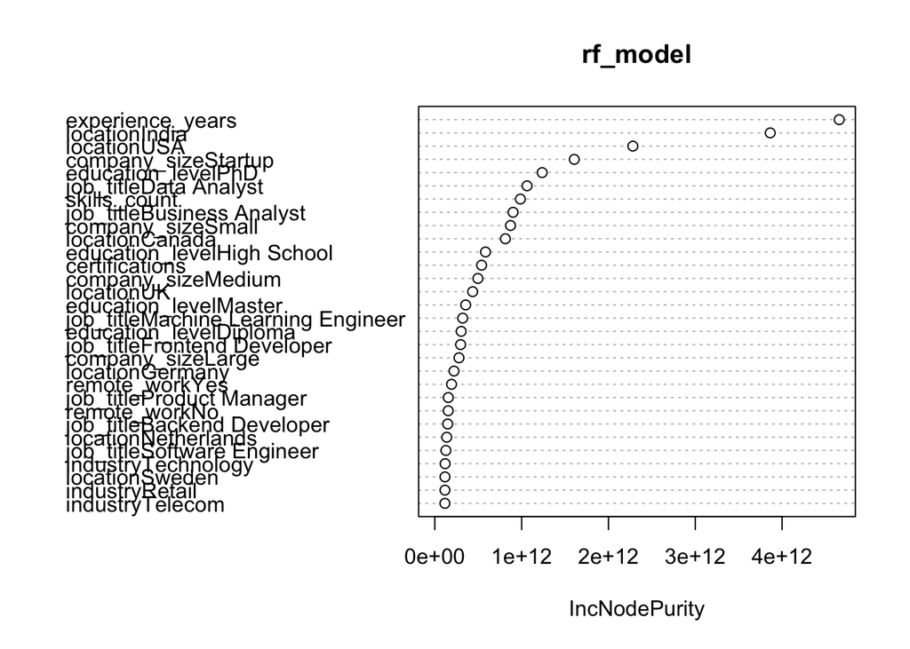

Figure 1: Random Forest Variable Importance

```r
varImpPlot(rf_model)
```

### Boosting

Boosting achieved the lowest test MSE of 46,731,953, making it the best-performing model. Different combinations of the number of trees, shrinkage rate and tree depth were tested. Lower shrinkage values and shallow trees improved performance by allowing the model to learn gradually and avoid overfitting. The sequential nature of boosting enables it to capture patterns that other models miss (Friedman, 2001).

Figure 2 demonstrates that Boosting assigned particularly high importance to location and experience.

```r
set.seed(123)
sample_index <- sample(1:nrow(train_data), 30000)

train_small <- train_data[sample_index, ]

boost_model <- gbm(
  salary ~ .,
  data = train_small,
  distribution = "gaussian",
  n.trees = 300,
  interaction.depth = 2,
  shrinkage = 0.05
)

pred_boost <- predict(boost_model, test_data, n.trees = 300)
mse_boost <- mean((test_data$salary - pred_boost)^2)
mse_boost
```

```
## [1] 46731953
```

### Boosting Importance

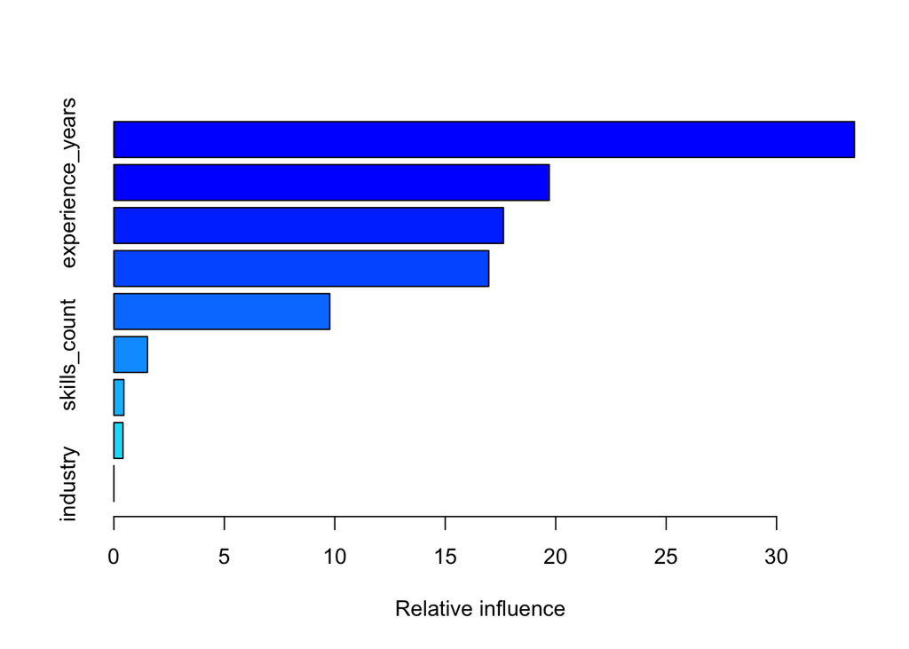

Figure 2: Boosting Variable Importance

```
##                               var    rel.inf
## location                 location 33.5244246
## experience_years experience_years 19.7113144
## company_size         company_size 17.6359671
## job_title               job_title 16.9708804
## education_level   education_level  9.7736244
## skills_count         skills_count  1.5191446
## certifications     certifications  0.4534345
## remote_work           remote_work  0.4112099
## industry                 industry  0.0000000
```

```r
summary(boost_model)
```

# FINAL COMPARISON TABLE

### Table 1: Model Performance (Test MSE)

```r
results <- data.frame(
  Model = c("Lasso", "Bagging", "Random Forest", "Boosting"),
  MSE = c(mse_lasso, mse_bag, mse_rf, mse_boost)
)

results
```

```
##           Model       MSE
## 1         Lasso  51084437
## 2       Bagging 125322635
## 3 Random Forest 184889132
## 4      Boosting  46731953
```

## 4. Limitations and Future Work

This analysis has several limitations. First, computational constraints required reducing sample sizes and limiting the number of trees, which may have affected model performance. Second, the dataset may not capture all relevant factors influencing salary, such as company performance or negotiation effects. Future work could include using the full dataset with more computational resources, testing additional models such as gradient boosting variants, incorporating interaction terms or feature engineering.

## 5. Conclusion

# Bibliography

Kaggle. (n.d.). Job Salary Prediction Dataset. https://www.kaggle.com/datasets/nalisha/job-salary-prediction-dataset

Breiman, L. (1996). Bagging predictors. Machine Learning. https://link.springer.com/article/10.1007/BF00058655

Breiman, L. (2001). Random forests. Machine Learning. https://link.springer.com/article/10.1023/A:1010933404324

Friedman, J. H. (2001). Greedy function approximation: A gradient boosting machine. Annals of Statistics.https://projecteuclid.org/journals/annals-of-statistics/volume-29/issue-5/Greedy-function-approximation-A-gradient-boosting-machine/10.1214/aos/1013203451.full

Hastie, T., Tibshirani, R., & Friedman, J. (2009). The Elements of Statistical Learning. https://hastie.su.domains/ElemStatLearn/

Tibshirani, R. (1996). Regression shrinkage and selection via the lasso. https://www.jstor.org/stable/2346178

OpenAI. (2026). ChatGPT (GPT-5.5) [Large language model]. https://chat.openai.com/